# Clustering and classification

In this exercise, linear discriminant analysis (LDA) and k-means clustering are used to classify data based on crime rate and to find clusters in the data.

## Data

The data used in this exercise is the Boston dataset from R’s MASS package. The data contains information about housing in the area of Boston and it has 506 observations and 14 variables. The summaries of the variables are displayed in the matrix below and more information about them can be found [here](https://stat.ethz.ch/R-manual/R-devel/library/MASS/html/Boston.html).

The correlation matrix demonstrates the relationships between the variables. Some of the variables have a clear positive or negative correlation, which seems obvious based on the nature of the variables. As for the summary matrix, it can be seen that the variables are very differently distributed compared to each other as different units of measurement are, of course, used.

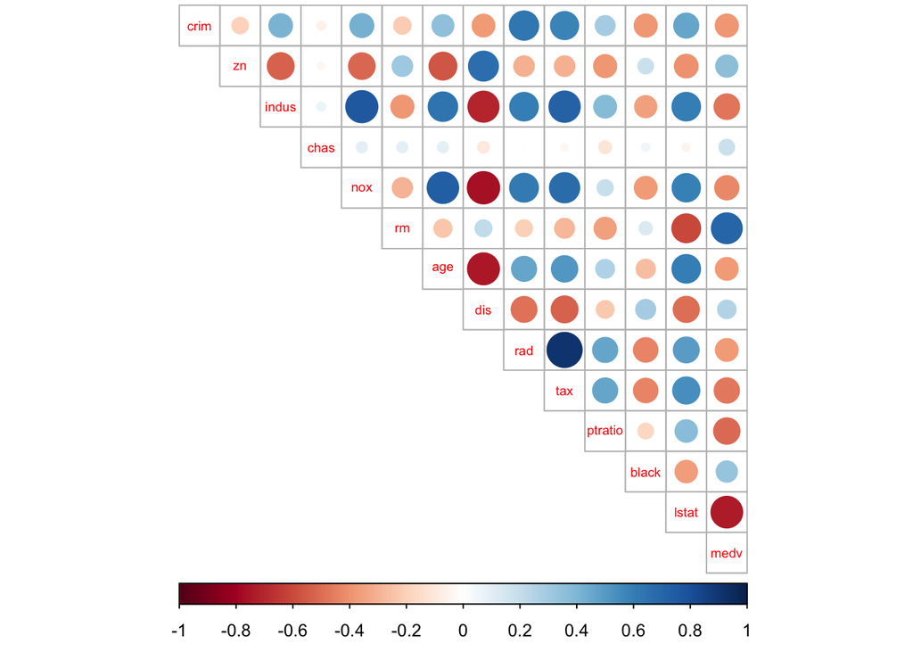

```r
cor_matrix<-cor(Boston)
cor_matrix %>% round( digits=2) %>% corrplot(method="circle", type = "upper", cl.pos = "b", tl.pos = "d", tl.cex = 0.6)
```

```r
summary(Boston)
```

```
##       crim                zn             indus            chas
##  Min.   : 0.00632   Min.   :  0.00   Min.   : 0.46   Min.   :0.00000
##  1st Qu.: 0.08204   1st Qu.:  0.00   1st Qu.: 5.19   1st Qu.:0.00000
##  Median : 0.25651   Median :  0.00   Median : 9.69   Median :0.00000
##  Mean   : 3.61352   Mean   : 11.36   Mean   :11.14   Mean   :0.06917
##  3rd Qu.: 3.67708   3rd Qu.: 12.50   3rd Qu.:18.10   3rd Qu.:0.00000
##  Max.   :88.97620   Max.   :100.00   Max.   :27.74   Max.   :1.00000
##       nox               rm             age              dis
##  Min.   :0.3850   Min.   :3.561   Min.   :  2.90   Min.   : 1.130
##  1st Qu.:0.4490   1st Qu.:5.886   1st Qu.: 45.02   1st Qu.: 2.100
##  Median :0.5380   Median :6.208   Median : 77.50   Median : 3.207
##  Mean   :0.5547   Mean   :6.285   Mean   : 68.57   Mean   : 3.795
##  3rd Qu.:0.6240   3rd Qu.:6.623   3rd Qu.: 94.08   3rd Qu.: 5.188
##  Max.   :0.8710   Max.   :8.780   Max.   :100.00   Max.   :12.127
##       rad              tax           ptratio          black
##  Min.   : 1.000   Min.   :187.0   Min.   :12.60   Min.   :  0.32
##  1st Qu.: 4.000   1st Qu.:279.0   1st Qu.:17.40   1st Qu.:375.38
##  Median : 5.000   Median :330.0   Median :19.05   Median :391.44
##  Mean   : 9.549   Mean   :408.2   Mean   :18.46   Mean   :356.67
##  3rd Qu.:24.000   3rd Qu.:666.0   3rd Qu.:20.20   3rd Qu.:396.23
##  Max.   :24.000   Max.   :711.0   Max.   :22.00   Max.   :396.90
##      lstat            medv
##  Min.   : 1.73   Min.   : 5.00
##  1st Qu.: 6.95   1st Qu.:17.02
##  Median :11.36   Median :21.20
##  Mean   :12.65   Mean   :22.53
##  3rd Qu.:16.95   3rd Qu.:25.00
##  Max.   :37.97   Max.   :50.00
```

### Scaling the data

For the purpose of later analysis, the whole data is standardized. As the summary matrix shows, the mean of every variable is now 0.

```r
boston_scaled <- scale(Boston)
summary(boston_scaled)
```

```
##       crim                 zn               indus
##  Min.   :-0.419367   Min.   :-0.48724   Min.   :-1.5563
##  1st Qu.:-0.410563   1st Qu.:-0.48724   1st Qu.:-0.8668
##  Median :-0.390280   Median :-0.48724   Median :-0.2109
##  Mean   : 0.000000   Mean   : 0.00000   Mean   : 0.0000
##  3rd Qu.: 0.007389   3rd Qu.: 0.04872   3rd Qu.: 1.0150
##  Max.   : 9.924110   Max.   : 3.80047   Max.   : 2.4202
##       chas              nox                rm               age
##  Min.   :-0.2723   Min.   :-1.4644   Min.   :-3.8764   Min.   :-2.3331
##  1st Qu.:-0.2723   1st Qu.:-0.9121   1st Qu.:-0.5681   1st Qu.:-0.8366
##  Median :-0.2723   Median :-0.1441   Median :-0.1084   Median : 0.3171
##  Mean   : 0.0000   Mean   : 0.0000   Mean   : 0.0000   Mean   : 0.0000
##  3rd Qu.:-0.2723   3rd Qu.: 0.5981   3rd Qu.: 0.4823   3rd Qu.: 0.9059
##  Max.   : 3.6648   Max.   : 2.7296   Max.   : 3.5515   Max.   : 1.1164
##       dis               rad               tax             ptratio
##  Min.   :-1.2658   Min.   :-0.9819   Min.   :-1.3127   Min.   :-2.7047
##  1st Qu.:-0.8049   1st Qu.:-0.6373   1st Qu.:-0.7668   1st Qu.:-0.4876
##  Median :-0.2790   Median :-0.5225   Median :-0.4642   Median : 0.2746
##  Mean   : 0.0000   Mean   : 0.0000   Mean   : 0.0000   Mean   : 0.0000
##  3rd Qu.: 0.6617   3rd Qu.: 1.6596   3rd Qu.: 1.5294   3rd Qu.: 0.8058
##  Max.   : 3.9566   Max.   : 1.6596   Max.   : 1.7964   Max.   : 1.6372
##      black             lstat              medv
##  Min.   :-3.9033   Min.   :-1.5296   Min.   :-1.9063
##  1st Qu.: 0.2049   1st Qu.:-0.7986   1st Qu.:-0.5989
##  Median : 0.3808   Median :-0.1811   Median :-0.1449
##  Mean   : 0.0000   Mean   : 0.0000   Mean   : 0.0000
##  3rd Qu.: 0.4332   3rd Qu.: 0.6024   3rd Qu.: 0.2683
##  Max.   : 0.4406   Max.   : 3.5453   Max.   : 2.9865
```

### Creating a categorical variable

After scaling, the continuous “crim”, indicating per capita crime rate by town, is recoded into four categories, and the original variable is replaced by the new categorical “crime” variable.

```r
scaled_crim <- boston_scaled$crim
bins <- quantile(scaled_crim)
crime <- cut(scaled_crim, breaks = bins, include.lowest = TRUE)
crime <- factor(crime, labels = c("low", "med_low", "med_high", "high"))
table(crime)
```

```
## crime
##      low  med_low med_high     high
##      127      126      126      127
```

```r
boston_scaled <- dplyr::select(boston_scaled, -crim)
boston_scaled <- data.frame(boston_scaled, crime)
```

## Linear Discriminant Analysis

### Creating train and test sets

Before the analysis, a train set containing 80 % of the observations in the data and a test set with 20 % of the observations are created.

```r
n <- 506
ind <- sample(n,  size = n * 0.8)
train <- boston_scaled[ind,]
test <- boston_scaled[-ind,]
```

### Analysis

Linear discriminant analysis (LDA) is used to find the variables that separate the classes of the categorical “crime” variable. The results of the analysis are displayed below.

The plot below visualizes the results of the analysis.

```r
lda.fit <- lda(crime ~ ., data = train)
lda.fit
```

```
## Call:
## lda(crime ~ ., data = train)
##
## Prior probabilities of groups:
##       low   med_low  med_high      high
## 0.2326733 0.2450495 0.2623762 0.2599010
##
## Group means:
##                   zn      indus        chas        nox         rm
## low       0.96989824 -0.9617196 -0.14667693 -0.8809212  0.4244067
## med_low  -0.09268391 -0.3221277 -0.11325431 -0.5558727 -0.1496829
## med_high -0.38935088  0.1816583  0.09909548  0.3794929  0.1370315
## high     -0.48724019  1.0170492 -0.04735191  1.0494662 -0.3417239
##                age        dis        rad        tax     ptratio      black
## low      -0.901983  0.8667051 -0.6959762 -0.7417580 -0.39664974  0.3880646
## med_low  -0.308323  0.3562438 -0.5398854 -0.4406594 -0.05877782  0.3212502
## med_high  0.490204 -0.3885994 -0.4163054 -0.3154301 -0.28187803  0.1204921
## high      0.784650 -0.8302137  1.6388211  1.5145512  0.78158339 -0.9185593
##                 lstat        medv
## low      -0.782168035  0.51729535
## med_low  -0.124522784 -0.01542847
## med_high -0.006373852  0.16496428
## high      0.832527101 -0.68587290
##
## Coefficients of linear discriminants:
##                 LD1         LD2         LD3
## zn       0.12159012  0.61917109 -1.08007004
## indus    0.09487709 -0.53195563  0.14390174
## chas    -0.06999893 -0.05187797  0.02621416
## nox      0.30849949 -0.57966711 -1.23150895
## rm      -0.12010416 -0.10755712 -0.17273560
## age      0.29627658 -0.46341008 -0.21419389
## dis     -0.08489120 -0.26706970  0.32102520
## rad      3.24934544  0.68494759 -0.37341106
## tax     -0.08555269  0.31246345  0.94388400
## ptratio  0.09832498  0.06355994 -0.28166922
## black   -0.12942258 -0.01144837  0.09461080
## lstat    0.14284092 -0.06761542  0.54977343
## medv     0.14185450 -0.23590507 -0.01078914
##
## Proportion of trace:
##    LD1    LD2    LD3
## 0.9451 0.0409 0.0139
```

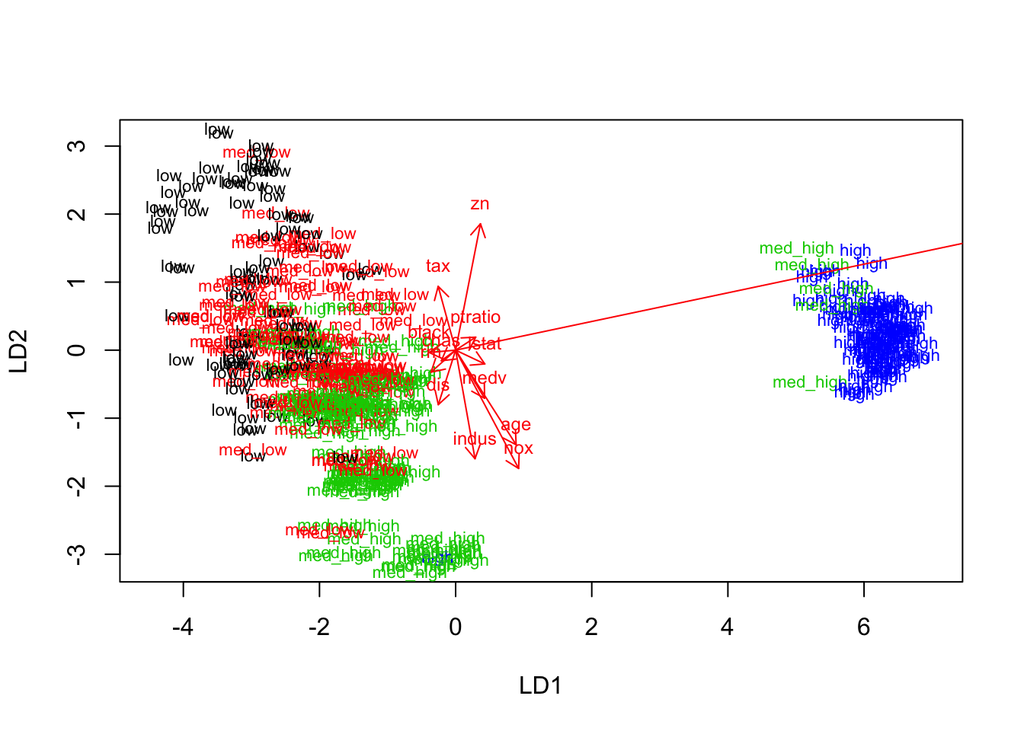

```r
lda.arrows <- function(x, myscale = 1, arrow_heads = 0.1, color = "red", tex = 0.75, choices = c(1,2)){
  heads <- coef(x)
  arrows(x0 = 0, y0 = 0,
         x1 = myscale * heads[,choices[1]],
         y1 = myscale * heads[,choices[2]], col=color, length = arrow_heads)
  text(myscale * heads[,choices], labels = row.names(heads),
       cex = tex, col=color, pos=3)
}
classes <- as.numeric(train$crime)

plot(lda.fit, dimen = 2, col = classes, pch = classes)
lda.arrows(lda.fit, myscale = 3)
```

### Testing the predictions

```r
correct_classes <- test$crime
test <- dplyr::select(test, -crime)
lda.pred <- predict(lda.fit, newdata = test)
table(correct = correct_classes, predicted = lda.pred$class)
```

```
##           predicted
## correct    low med_low med_high high
##   low       20      11        2    0
##   med_low    5      18        4    0
##   med_high   0       9       10    1
##   high       0       0        0   22
```

## Clustering by k-means

The original Boston data (with the continuous “crim” variable) is scaled and the Euclidean distances between the observations are counted in order to use the k-means algorithm. After trying with a few different number of clusters, it seems like two clusters separate the data the best. The scatter plot matrix below demonstrates the clusters in two dimensions. It seems like at least variables “tax” and “rad” are clear separators.

```r
boston <- scale(Boston)
boston <- as.data.frame(boston)
dist_eu <- dist(boston)
summary(dist_eu)
```

```
##    Min. 1st Qu.  Median    Mean 3rd Qu.    Max.
##  0.1343  3.4620  4.8240  4.9110  6.1860 14.4000
```

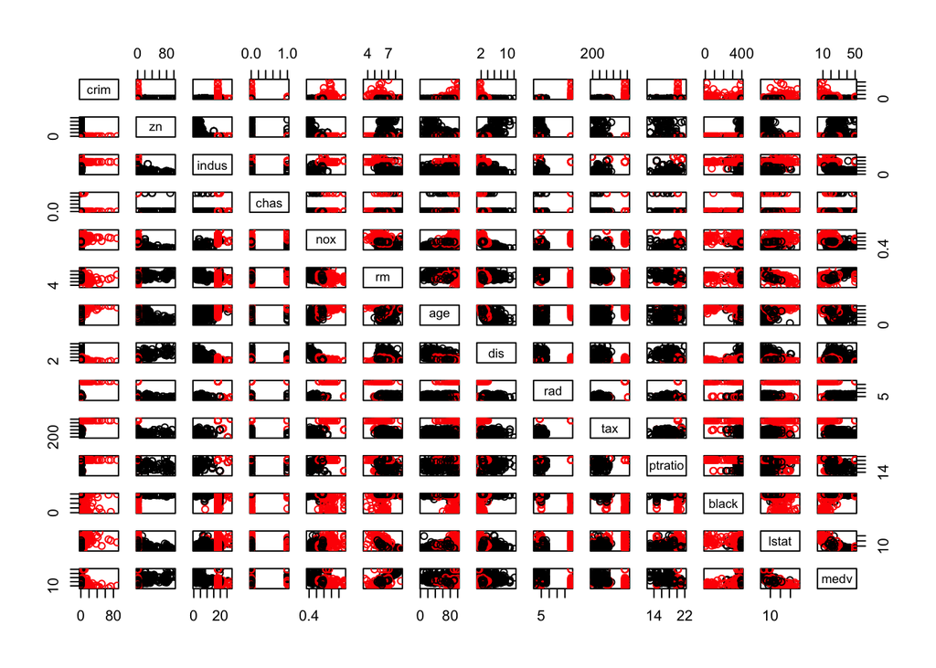

```r
km <-kmeans(dist_eu, centers = 2)
pairs(Boston, col = km$cluster)
```

### LDA on clusters

```r
km2 <-kmeans(dist_eu, centers = 3)
lda.fit2 <- lda(km2$cluster ~ ., data = boston)
lda.fit2
```

```
## Call:
## lda(km2$cluster ~ ., data = boston)
##
## Prior probabilities of groups:
##         1         2         3
## 0.4545455 0.3379447 0.2075099
##
## Group means:
##         crim         zn      indus        chas        nox         rm
## 1 -0.3836903 -0.2417220 -0.3961699 -0.27232907 -0.4622965 -0.1362230
## 2  0.7572682 -0.4872402  1.1014137  0.09605458  1.0883702 -0.4660727
## 3 -0.3928010  1.3229917 -0.9259301  0.44009859 -0.7598391  1.0574260
##          age        dis        rad        tax     ptratio      black
## 1 -0.2436777  0.2523399 -0.5819051 -0.6076728  0.02174424  0.3090727
## 2  0.8016262 -0.8432429  1.1458150  1.2111947  0.55861853 -0.6268442
## 3 -0.7717354  0.8205368 -0.5913924 -0.6414244 -0.95738042  0.3438442
##        lstat        medv
## 1 -0.2420506 -0.03505142
## 2  0.8670686 -0.66472098
## 3 -0.8818772  1.15932490
##
## Coefficients of linear discriminants:
##                 LD1         LD2
## crim    -0.02888613  0.15059842
## zn       0.19021173  1.19748109
## indus    0.74772214 -0.01199683
## chas     0.09725660  0.47536603
## nox      0.84565514  0.38351766
## rm      -0.09589403  0.48812607
## age     -0.13170086 -0.08411580
## dis      0.06277612  0.11575438
## rad      0.76263747 -0.17554557
## tax      0.62543787  0.69318490
## ptratio  0.18516563 -0.11053258
## black   -0.07029190 -0.05865397
## lstat    0.28604098  0.56753341
## medv     0.02298635  0.77450418
##
## Proportion of trace:
##    LD1    LD2
## 0.7909 0.2091
```

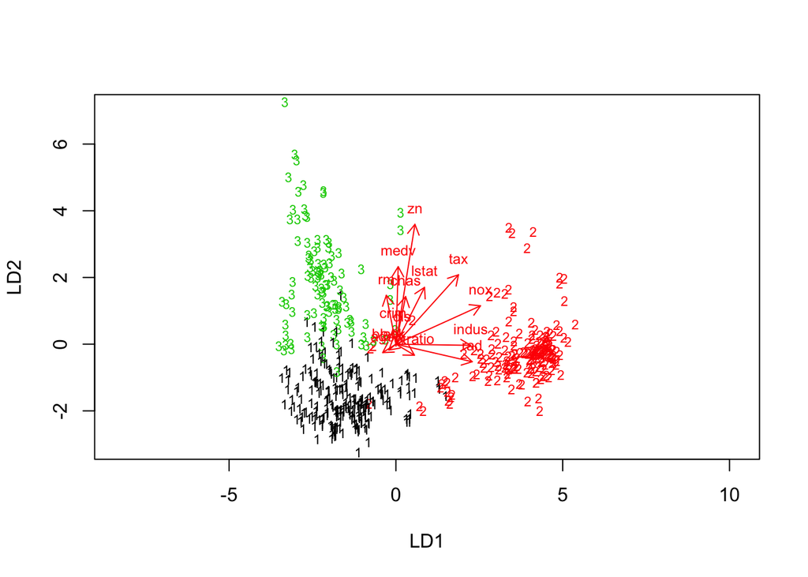

```r
lda.arrows <- function(x, myscale = 1, arrow_heads = 0.1, color = "red", tex = 0.75, choices = c(1,2)){
  heads <- coef(x)
  arrows(x0 = 0, y0 = 0,
         x1 = myscale * heads[,choices[1]],
         y1 = myscale * heads[,choices[2]], col=color, length = arrow_heads)
  text(myscale * heads[,choices], labels = row.names(heads),
       cex = tex, col=color, pos=3)
}

classes2 <- as.numeric(km2$cluster)

plot(lda.fit2, dimen = 2, col = classes2, pch = classes2)
lda.arrows(lda.fit2, myscale = 3)
```